# Risk Factor Analysis

## Outcome Variable

**Outcome Variable:** wasted

## Predictor Variables

**Intervention Variable:** predfeed6

**Adjustment Set:**

unadjusted

## Stratifying Variables

The analysis was stratified on these variable(s):

- agecat
- studyid
- country

## Data Summary

| agecat | studyid | country | predfeed6 | wasted | n_cell | n |
| --- | --- | --- | --- | --- | --- | --- |
| Birth | ki0047075b-MAL-ED | BANGLADESH | 0 | 0 | 83 | 219 |
| Birth | ki0047075b-MAL-ED | BANGLADESH | 0 | 1 | 22 | 219 |
| Birth | ki0047075b-MAL-ED | BANGLADESH | 1 | 0 | 98 | 219 |
| Birth | ki0047075b-MAL-ED | BANGLADESH | 1 | 1 | 16 | 219 |
| Birth | ki0047075b-MAL-ED | BRAZIL | 0 | 0 | 136 | 168 |
| Birth | ki0047075b-MAL-ED | BRAZIL | 0 | 1 | 6 | 168 |
| Birth | ki0047075b-MAL-ED | BRAZIL | 1 | 0 | 26 | 168 |
| Birth | ki0047075b-MAL-ED | BRAZIL | 1 | 1 | 0 | 168 |
| Birth | ki0047075b-MAL-ED | INDIA | 0 | 0 | 144 | 187 |
| Birth | ki0047075b-MAL-ED | INDIA | 0 | 1 | 28 | 187 |
| Birth | ki0047075b-MAL-ED | INDIA | 1 | 0 | 13 | 187 |
| Birth | ki0047075b-MAL-ED | INDIA | 1 | 1 | 2 | 187 |
| Birth | ki0047075b-MAL-ED | NEPAL | 0 | 0 | 124 | 165 |
| Birth | ki0047075b-MAL-ED | NEPAL | 0 | 1 | 19 | 165 |
| Birth | ki0047075b-MAL-ED | NEPAL | 1 | 0 | 21 | 165 |
| Birth | ki0047075b-MAL-ED | NEPAL | 1 | 1 | 1 | 165 |
| Birth | ki0047075b-MAL-ED | PERU | 0 | 0 | 141 | 249 |
| Birth | ki0047075b-MAL-ED | PERU | 0 | 1 | 4 | 249 |
| Birth | ki0047075b-MAL-ED | PERU | 1 | 0 | 103 | 249 |
| Birth | ki0047075b-MAL-ED | PERU | 1 | 1 | 1 | 249 |
| Birth | ki0047075b-MAL-ED | SOUTH AFRICA | 0 | 0 | 192 | 209 |
| Birth | ki0047075b-MAL-ED | SOUTH AFRICA | 0 | 1 | 14 | 209 |
| Birth | ki0047075b-MAL-ED | SOUTH AFRICA | 1 | 0 | 3 | 209 |
| Birth | ki0047075b-MAL-ED | SOUTH AFRICA | 1 | 1 | 0 | 209 |
| Birth | ki0047075b-MAL-ED | TANZANIA, UNITED REPUBLIC OF | 0 | 0 | 112 | 115 |
| Birth | ki0047075b-MAL-ED | TANZANIA, UNITED REPUBLIC OF | 0 | 1 | 2 | 115 |
| Birth | ki0047075b-MAL-ED | TANZANIA, UNITED REPUBLIC OF | 1 | 0 | 1 | 115 |
| Birth | ki0047075b-MAL-ED | TANZANIA, UNITED REPUBLIC OF | 1 | 1 | 0 | 115 |
| Birth | ki1000109-EE | PAKISTAN | 0 | 0 | 2 | 2 |
| Birth | ki1000109-EE | PAKISTAN | 0 | 1 | 0 | 2 |

[output cut: 106 more lines]

The following strata were considered:

- agecat: 24 months, studyid: ki0047075b-MAL-ED, country: BANGLADESH
- agecat: 24 months, studyid: ki0047075b-MAL-ED, country: BRAZIL
- agecat: 24 months, studyid: ki0047075b-MAL-ED, country: INDIA
- agecat: 24 months, studyid: ki0047075b-MAL-ED, country: NEPAL
- agecat: 24 months, studyid: ki0047075b-MAL-ED, country: PERU
- agecat: 24 months, studyid: ki0047075b-MAL-ED, country: SOUTH AFRICA
- agecat: 24 months, studyid: ki0047075b-MAL-ED, country: TANZANIA, UNITED REPUBLIC OF
- agecat: 24 months, studyid: ki1113344-GMS-Nepal, country: NEPAL
- agecat: 24 months, studyid: ki1148112-LCNI-5, country: MALAWI
- agecat: 24 months, studyid: kiGH5241-JiVitA-3, country: BANGLADESH
- agecat: 24 months, studyid: kiGH5241-JiVitA-4, country: BANGLADESH
- agecat: 6 months, studyid: ki0047075b-MAL-ED, country: BANGLADESH
- agecat: 6 months, studyid: ki0047075b-MAL-ED, country: BRAZIL
- agecat: 6 months, studyid: ki0047075b-MAL-ED, country: INDIA
- agecat: 6 months, studyid: ki0047075b-MAL-ED, country: NEPAL
- agecat: 6 months, studyid: ki0047075b-MAL-ED, country: PERU
- agecat: 6 months, studyid: ki0047075b-MAL-ED, country: SOUTH AFRICA
- agecat: 6 months, studyid: ki0047075b-MAL-ED, country: TANZANIA, UNITED REPUBLIC OF
- agecat: 6 months, studyid: ki1000109-EE, country: PAKISTAN
- agecat: 6 months, studyid: ki1000304b-SAS-FoodSuppl, country: INDIA
- agecat: 6 months, studyid: ki1113344-GMS-Nepal, country: NEPAL
- agecat: 6 months, studyid: ki1148112-LCNI-5, country: MALAWI
- agecat: 6 months, studyid: kiGH5241-JiVitA-3, country: BANGLADESH
- agecat: 6 months, studyid: kiGH5241-JiVitA-4, country: BANGLADESH
- agecat: Birth, studyid: ki0047075b-MAL-ED, country: BANGLADESH
- agecat: Birth, studyid: ki0047075b-MAL-ED, country: BRAZIL
- agecat: Birth, studyid: ki0047075b-MAL-ED, country: INDIA
- agecat: Birth, studyid: ki0047075b-MAL-ED, country: NEPAL
- agecat: Birth, studyid: ki0047075b-MAL-ED, country: PERU
- agecat: Birth, studyid: ki0047075b-MAL-ED, country: SOUTH AFRICA
- agecat: Birth, studyid: ki0047075b-MAL-ED, country: TANZANIA, UNITED REPUBLIC OF
- agecat: Birth, studyid: ki1000109-EE, country: PAKISTAN
- agecat: Birth, studyid: kiGH5241-JiVitA-3, country: BANGLADESH
- agecat: Birth, studyid: kiGH5241-JiVitA-4, country: BANGLADESH

### Dropped Strata

Some strata were dropped due to rare outcomes:

- agecat: Birth, studyid: ki0047075b-MAL-ED, country: BRAZIL
- agecat: Birth, studyid: ki0047075b-MAL-ED, country: INDIA
- agecat: Birth, studyid: ki0047075b-MAL-ED, country: NEPAL
- agecat: Birth, studyid: ki0047075b-MAL-ED, country: PERU
- agecat: Birth, studyid: ki0047075b-MAL-ED, country: SOUTH AFRICA
- agecat: Birth, studyid: ki0047075b-MAL-ED, country: TANZANIA, UNITED REPUBLIC OF
- agecat: Birth, studyid: ki1000109-EE, country: PAKISTAN
- agecat: 6 months, studyid: ki0047075b-MAL-ED, country: BANGLADESH
- agecat: 6 months, studyid: ki0047075b-MAL-ED, country: BRAZIL
- agecat: 6 months, studyid: ki0047075b-MAL-ED, country: INDIA
- agecat: 6 months, studyid: ki0047075b-MAL-ED, country: NEPAL
- agecat: 6 months, studyid: ki0047075b-MAL-ED, country: PERU
- agecat: 6 months, studyid: ki0047075b-MAL-ED, country: SOUTH AFRICA
- agecat: 6 months, studyid: ki0047075b-MAL-ED, country: TANZANIA, UNITED REPUBLIC OF
- agecat: 6 months, studyid: ki1000304b-SAS-FoodSuppl, country: INDIA
- agecat: 6 months, studyid: ki1148112-LCNI-5, country: MALAWI
- agecat: 24 months, studyid: ki0047075b-MAL-ED, country: BRAZIL
- agecat: 24 months, studyid: ki0047075b-MAL-ED, country: INDIA
- agecat: 24 months, studyid: ki0047075b-MAL-ED, country: NEPAL
- agecat: 24 months, studyid: ki0047075b-MAL-ED, country: PERU
- agecat: 24 months, studyid: ki0047075b-MAL-ED, country: SOUTH AFRICA
- agecat: 24 months, studyid: ki0047075b-MAL-ED, country: TANZANIA, UNITED REPUBLIC OF
- agecat: 24 months, studyid: ki1148112-LCNI-5, country: MALAWI

## Methods Detail

We’re interested in the causal parameters $E[Y_a]$ for all values of $a \in \mathcal{A}$. These parameters represent the mean outcome if, possibly contrary to fact, we intervened to set all units to have $A=a$. Under the randomization and positivity assumptions, these are identified by the statistical parameters $\psi_a=E_W[E_{Y|A,W}(Y|A=a,W)]$. In addition, we’re interested in the mean of $Y$, $E[Y]$ under no intervention (the observed mean). We will estimate these parameters by using SuperLearner to fit the relevant likelihood factors – $E_{Y|A,W}(Y|A=a,W)$ and $p(A=a|W)$, and then updating our likelihood fit using a joint TMLE.

For unadjusted analyses ($W=\{\}$), initial likelihoods were estimated using Lrnr_glm to estimate the simple $E(Y|A)$ and Lrnr_mean to estimate $p(A)$. For adjusted analyses, a small library containing Lrnr_glmnet, Lrnr_xgboost, and Lrnr_mean was used.

Having estimated these parameters, we will then use the delta method to estimate relative risks and attributable risks relative to a prespecified baseline level of $A$.

# Results Detail

## Results Plots

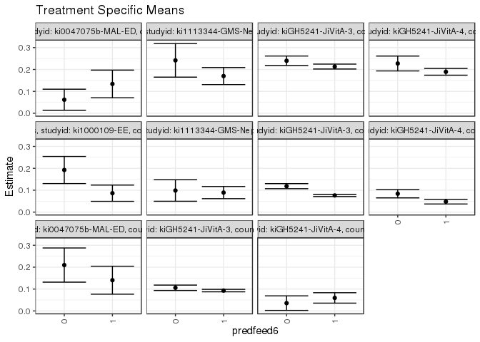

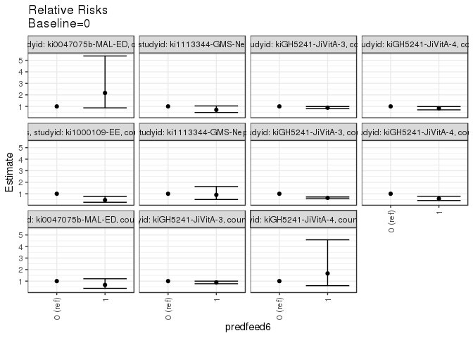

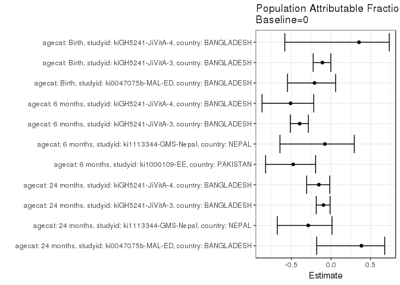

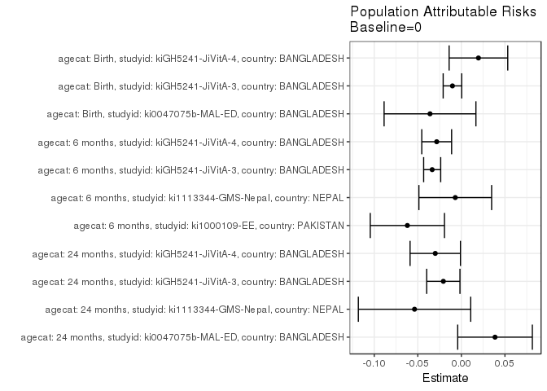

## Results Table

### Parameter: TSM

| agecat | studyid | country | intervention_level | baseline_level | estimate | ci_lower | ci_upper |
| --- | --- | --- | --- | --- | --- | --- | --- |
| Birth | ki0047075b-MAL-ED | BANGLADESH | 0 | NA | 0.2095238 | 0.1315034 | 0.2875442 |
| Birth | ki0047075b-MAL-ED | BANGLADESH | 1 | NA | 0.1403509 | 0.0764425 | 0.2042592 |
| Birth | kiGH5241-JiVitA-3 | BANGLADESH | 0 | NA | 0.1057851 | 0.0935333 | 0.1180370 |
| Birth | kiGH5241-JiVitA-3 | BANGLADESH | 1 | NA | 0.0930214 | 0.0873920 | 0.0986508 |
| Birth | kiGH5241-JiVitA-4 | BANGLADESH | 0 | NA | 0.0357143 | 0.0025801 | 0.0688485 |
| Birth | kiGH5241-JiVitA-4 | BANGLADESH | 1 | NA | 0.0595010 | 0.0357033 | 0.0832986 |
| 6 months | ki1000109-EE | PAKISTAN | 0 | NA | 0.1923077 | 0.1303799 | 0.2542355 |
| 6 months | ki1000109-EE | PAKISTAN | 1 | NA | 0.0863636 | 0.0491958 | 0.1235315 |
| 6 months | ki1113344-GMS-Nepal | NEPAL | 0 | NA | 0.0985915 | 0.0495140 | 0.1476691 |
| 6 months | ki1113344-GMS-Nepal | NEPAL | 1 | NA | 0.0891089 | 0.0613022 | 0.1169156 |
| 6 months | kiGH5241-JiVitA-3 | BANGLADESH | 0 | NA | 0.1184779 | 0.1069374 | 0.1300185 |
| 6 months | kiGH5241-JiVitA-3 | BANGLADESH | 1 | NA | 0.0761414 | 0.0710298 | 0.0812530 |
| 6 months | kiGH5241-JiVitA-4 | BANGLADESH | 0 | NA | 0.0839612 | 0.0649300 | 0.1029925 |
| 6 months | kiGH5241-JiVitA-4 | BANGLADESH | 1 | NA | 0.0477334 | 0.0370754 | 0.0583914 |
| 24 months | ki0047075b-MAL-ED | BANGLADESH | 0 | NA | 0.0618557 | 0.0138018 | 0.1099095 |
| 24 months | ki0047075b-MAL-ED | BANGLADESH | 1 | NA | 0.1339286 | 0.0707028 | 0.1971543 |
| 24 months | ki1113344-GMS-Nepal | NEPAL | 0 | NA | 0.2416667 | 0.1649924 | 0.3183410 |
| 24 months | ki1113344-GMS-Nepal | NEPAL | 1 | NA | 0.1699164 | 0.1310269 | 0.2088060 |
| 24 months | kiGH5241-JiVitA-3 | BANGLADESH | 0 | NA | 0.2397849 | 0.2181526 | 0.2614173 |
| 24 months | kiGH5241-JiVitA-3 | BANGLADESH | 1 | NA | 0.2132872 | 0.2020823 | 0.2244922 |
| 24 months | kiGH5241-JiVitA-4 | BANGLADESH | 0 | NA | 0.2273756 | 0.1933771 | 0.2613740 |
| 24 months | kiGH5241-JiVitA-4 | BANGLADESH | 1 | NA | 0.1893130 | 0.1739403 | 0.2046857 |

### Parameter: E(Y)

| agecat | studyid | country | intervention_level | baseline_level | estimate | ci_lower | ci_upper |
| --- | --- | --- | --- | --- | --- | --- | --- |
| Birth | ki0047075b-MAL-ED | BANGLADESH | NA | NA | 0.1735160 | 0.1232462 | 0.2237857 |
| Birth | kiGH5241-JiVitA-3 | BANGLADESH | NA | NA | 0.0955253 | 0.0903072 | 0.1007433 |
| Birth | kiGH5241-JiVitA-4 | BANGLADESH | NA | NA | 0.0552923 | 0.0348344 | 0.0757501 |
| 6 months | ki1000109-EE | PAKISTAN | NA | NA | 0.1303191 | 0.0962457 | 0.1643926 |
| 6 months | ki1113344-GMS-Nepal | NEPAL | NA | NA | 0.0915751 | 0.0673602 | 0.1157900 |
| 6 months | kiGH5241-JiVitA-3 | BANGLADESH | NA | NA | 0.0849595 | 0.0801414 | 0.0897775 |
| 6 months | kiGH5241-JiVitA-4 | BANGLADESH | NA | NA | 0.0556338 | 0.0463917 | 0.0648759 |
| 24 months | ki0047075b-MAL-ED | BANGLADESH | NA | NA | 0.1004785 | 0.0596222 | 0.1413347 |
| 24 months | ki1113344-GMS-Nepal | NEPAL | NA | NA | 0.1878914 | 0.1528732 | 0.2229097 |
| 24 months | kiGH5241-JiVitA-3 | BANGLADESH | NA | NA | 0.2190767 | 0.2091475 | 0.2290059 |
| 24 months | kiGH5241-JiVitA-4 | BANGLADESH | NA | NA | 0.1974032 | 0.1830515 | 0.2117549 |

### Parameter: RR

| agecat | studyid | country | intervention_level | baseline_level | estimate | ci_lower | ci_upper |
| --- | --- | --- | --- | --- | --- | --- | --- |
| Birth | ki0047075b-MAL-ED | BANGLADESH | 0 | 0 | 1.0000000 | 1.0000000 | 1.0000000 |
| Birth | ki0047075b-MAL-ED | BANGLADESH | 1 | 0 | 0.6698565 | 0.3719820 | 1.2062619 |
| Birth | kiGH5241-JiVitA-3 | BANGLADESH | 0 | 0 | 1.0000000 | 1.0000000 | 1.0000000 |
| Birth | kiGH5241-JiVitA-3 | BANGLADESH | 1 | 0 | 0.8793427 | 0.7735513 | 0.9996023 |
| Birth | kiGH5241-JiVitA-4 | BANGLADESH | 0 | 0 | 1.0000000 | 1.0000000 | 1.0000000 |
| Birth | kiGH5241-JiVitA-4 | BANGLADESH | 1 | 0 | 1.6660269 | 0.6055423 | 4.5837352 |
| 6 months | ki1000109-EE | PAKISTAN | 0 | 0 | 1.0000000 | 1.0000000 | 1.0000000 |
| 6 months | ki1000109-EE | PAKISTAN | 1 | 0 | 0.4490909 | 0.2623603 | 0.7687238 |
| 6 months | ki1113344-GMS-Nepal | NEPAL | 0 | 0 | 1.0000000 | 1.0000000 | 1.0000000 |
| 6 months | ki1113344-GMS-Nepal | NEPAL | 1 | 0 | 0.9038190 | 0.5022605 | 1.6264243 |
| 6 months | kiGH5241-JiVitA-3 | BANGLADESH | 0 | 0 | 1.0000000 | 1.0000000 | 1.0000000 |
| 6 months | kiGH5241-JiVitA-3 | BANGLADESH | 1 | 0 | 0.6426627 | 0.5729475 | 0.7208608 |
| 6 months | kiGH5241-JiVitA-4 | BANGLADESH | 0 | 0 | 1.0000000 | 1.0000000 | 1.0000000 |
| 6 months | kiGH5241-JiVitA-4 | BANGLADESH | 1 | 0 | 0.5685172 | 0.4129878 | 0.7826183 |
| 24 months | ki0047075b-MAL-ED | BANGLADESH | 0 | 0 | 1.0000000 | 1.0000000 | 1.0000000 |
| 24 months | ki0047075b-MAL-ED | BANGLADESH | 1 | 0 | 2.1651786 | 0.8723550 | 5.3739567 |
| 24 months | ki1113344-GMS-Nepal | NEPAL | 0 | 0 | 1.0000000 | 1.0000000 | 1.0000000 |
| 24 months | ki1113344-GMS-Nepal | NEPAL | 1 | 0 | 0.7031025 | 0.4754644 | 1.0397268 |
| 24 months | kiGH5241-JiVitA-3 | BANGLADESH | 0 | 0 | 1.0000000 | 1.0000000 | 1.0000000 |
| 24 months | kiGH5241-JiVitA-3 | BANGLADESH | 1 | 0 | 0.8894939 | 0.8011716 | 0.9875529 |
| 24 months | kiGH5241-JiVitA-4 | BANGLADESH | 0 | 0 | 1.0000000 | 1.0000000 | 1.0000000 |
| 24 months | kiGH5241-JiVitA-4 | BANGLADESH | 1 | 0 | 0.8326004 | 0.7043408 | 0.9842158 |

### Parameter: PAR

| agecat | studyid | country | intervention_level | baseline_level | estimate | ci_lower | ci_upper |
| --- | --- | --- | --- | --- | --- | --- | --- |
| Birth | ki0047075b-MAL-ED | BANGLADESH | 0 | NA | -0.0360078 | -0.0887070 | 0.0166914 |
| Birth | kiGH5241-JiVitA-3 | BANGLADESH | 0 | NA | -0.0102598 | -0.0209054 | 0.0003858 |
| Birth | kiGH5241-JiVitA-4 | BANGLADESH | 0 | NA | 0.0195780 | -0.0140625 | 0.0532184 |
| 6 months | ki1000109-EE | PAKISTAN | 0 | NA | -0.0619885 | -0.1045770 | -0.0194001 |
| 6 months | ki1113344-GMS-Nepal | NEPAL | 0 | NA | -0.0070165 | -0.0487554 | 0.0347225 |
| 6 months | kiGH5241-JiVitA-3 | BANGLADESH | 0 | NA | -0.0335185 | -0.0432948 | -0.0237421 |
| 6 months | kiGH5241-JiVitA-4 | BANGLADESH | 0 | NA | -0.0283274 | -0.0454501 | -0.0112048 |
| 24 months | ki0047075b-MAL-ED | BANGLADESH | 0 | NA | 0.0386228 | -0.0042137 | 0.0814593 |
| 24 months | ki1113344-GMS-Nepal | NEPAL | 0 | NA | -0.0537752 | -0.1182703 | 0.0107199 |
| 24 months | kiGH5241-JiVitA-3 | BANGLADESH | 0 | NA | -0.0207082 | -0.0397899 | -0.0016266 |
| 24 months | kiGH5241-JiVitA-4 | BANGLADESH | 0 | NA | -0.0299723 | -0.0588831 | -0.0010616 |

### Parameter: PAF

| agecat | studyid | country | intervention_level | baseline_level | estimate | ci_lower | ci_upper |
| --- | --- | --- | --- | --- | --- | --- | --- |
| Birth | ki0047075b-MAL-ED | BANGLADESH | 0 | NA | -0.2075188 | -0.5490556 | 0.0587158 |
| Birth | kiGH5241-JiVitA-3 | BANGLADESH | 0 | NA | -0.1074044 | -0.2242599 | -0.0017026 |
| Birth | kiGH5241-JiVitA-4 | BANGLADESH | 0 | NA | 0.3540816 | -0.5823543 | 0.7363356 |
| 6 months | ki1000109-EE | PAKISTAN | 0 | NA | -0.4756672 | -0.8247395 | -0.1933723 |
| 6 months | ki1113344-GMS-Nepal | NEPAL | 0 | NA | -0.0766197 | -0.6435372 | 0.2947467 |
| 6 months | kiGH5241-JiVitA-3 | BANGLADESH | 0 | NA | -0.3945231 | -0.5131175 | -0.2852239 |
| 6 months | kiGH5241-JiVitA-4 | BANGLADESH | 0 | NA | -0.5091769 | -0.8698279 | -0.2180880 |
| 24 months | ki0047075b-MAL-ED | BANGLADESH | 0 | NA | 0.3843888 | -0.1805817 | 0.6789912 |
| 24 months | ki1113344-GMS-Nepal | NEPAL | 0 | NA | -0.2862037 | -0.6774310 | 0.0137777 |
| 24 months | kiGH5241-JiVitA-3 | BANGLADESH | 0 | NA | -0.0945251 | -0.1852346 | -0.0107578 |
| 24 months | kiGH5241-JiVitA-4 | BANGLADESH | 0 | NA | -0.1518331 | -0.3067516 | -0.0152806 |